# Final dplyr and ggplot introduction

March 8th, 2018

## Before we start

Required packages and data:

- `dplyr`: obviously
- `ggplot2`: new package
- `storms.csv`: climate data for Central America (on MOLE)

**1. Load the `ggplot2` package**

```r
library("ggplot2")
```

This should already be installed. If you see errors, you may have to install it, e.g.

```r
install.packages("ggplot2")
```

Do the same for `dplyr` (you should NOT need to install it first)

**2. Read in the storms data**

Set your working directory to the correct location and then use `read.csv` to read the `storms.csv` data in (remember to use `stringsAsFactors = FALSE`), giving it the name `storms`.

## Using `%>%`

### piping or chaining

## Motivating example

We often need to perform a sequence of calculations on a vector or data frame. We do this by applying a series of function in sequence. Here are two ways to do this:

**Method 1: Store intermediate results…**

```r
x <- 10
x <- sqrt(x)
x <- exp(x)
round(x, 2)
```

```
## [1] 23.62
```

**Method 2: Use function nesting…**

```r
round(exp(sqrt(10)), 2)
```

```
## [1] 23.62
```

These do the same thing. Method 1 is easy to read, but is very verbose. Method 2 is concise, but not at all easy to read.

## A third way, using `%>%`…

The `dplyr` package includes a special operator, called "the pipe". It looks like this: `%>%`. This allows us to avoid storing intermediate results (method 1), while reading a sequence of function calls from left to right. For example:

```r
10 %>% sqrt(.) %>% exp(.) %>% round(., 2)
```

```
## [1] 23.62
```

Or equivalently, and even simpler…

```r
10 %>% sqrt() %>% exp() %>% round(2)
```

```
## [1] 23.62
```

## Why is this handy?

We can use `%>%` with any function we like. Look at this example of a two-step `group_by` and `summarise` operation with `iris`…

```r
# method 1
iris.grouped <- group_by(iris, Species)
summarise(iris.grouped, mean.SL = mean(Sepal.Length))

# method 2
summarise(group_by(iris, Species), mean.SL = mean(Sepal.Length))
```

The "piped" equivalent is more natural to read…

```r
iris %>%
  group_by(Species) %>%
  summarise(mean.SL = mean(Sepal.Length))
```

```
## # A tibble: 3 × 2
##      Species mean.SL
##       <fctr>   <dbl>
## 1     setosa   5.006
## 2 versicolor   5.936
## 3  virginica   6.588
```

## Exercise

**Using `group_by` to calculate group specific summaries**

Last week we used `group_by` and `summarise` with the `storms` data set to calculate the mean wind speed associated with each type of storm. Repeat this exercise now using the pipe.

```r
storms %>%
  group_by(type) %>%
  summarise(mean_speed = mean(wind))
```

```
## # A tibble: 4 × 2
##                  type mean_speed
##                 <chr>      <dbl>
## 1       Extratropical   40.06068
## 2           Hurricane   84.65960
## 3 Tropical Depression   27.35867
## 4      Tropical Storm   47.32181
```

## Overview of `ggplot2`

### The grammar of graphics

## Why use `ggplot2`?

Roughly speaking, there are three commonly used plotting frameworks in R.

- base graphics: available as soon as you open R
- `lattice` package
- `ggplot2` package

**Advantages** of using `ggplot2`

- Consistent and intuitive framework for plotting
- Flexible enough to make every plot you will need
- Works well with `dplyr`

**Disadvantages** of using `ggplot2`

- You have to learn "the grammar" to use it well
- Vast package, can be intimidating
- More than one way to do things

## Key concepts

You need to wrap your head around a few ideas to start using `ggplot2` effectively:

- **layers**: We build ggplot2 objects by adding one or more layers together. We can do this in a stepwise way, only plotting the object when we are ready. Each layer needs things like data, aesthetics, geometric objects, etc
- **aesthetics**: The word aesthetics refers to **the information** in a plot. For example, which variables are associated with the x and y axes? We specify this using the `aes` function.
- **geometric objects**: Geometric objects ("geoms") determine how the information is displayed. For example, will it be a scatter plot or a bar plot? We can specify geoms by adding a layer via functions beginning with `geom_`.

In practice, we build up a plot by combining different functions using the `+` operator. This has nothing to do with numeric addition!

## Illustrative example

Set up the basic object–define a default data frame and aesthetic…

```r
ggplot_object <- ggplot(my_df, aes(x = var1, y = var2))
```

Add a layer using the point 'geom'…

```r
ggplot_object <- ggplot_object + geom_point()
```

Show the plot–just 'print' the object to the console

```r
ggplot_object
```

## Real example: scatter plots

Scatter plots are used to show the relationship between 2 continuous variables. Using the `iris` dataset, let's examine the relationship between petal length and petal width.

**STEP 1**:

We use the `aes` function inside the `ggplot` function to specify which variables we plan to display. We also have to specify where the data are:

```r
plt <- ggplot(iris, aes(x = Petal.Width, y = Petal.Length))
```

All we did here was make a `ggplot` object.

## Real example: scatter plots

We can try to print the plot to the screen:

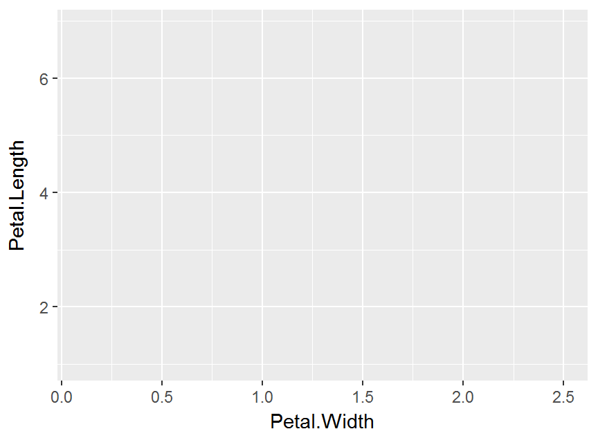

```r
plt
```

This produces an empty plot because we haven't added a layer using a `geom_` function yet.

## Real example: scatter plots

**STEP 2**:

We want to make a scatter plot so we need to use the `geom_point` function:

```r
plt <- plt + geom_point()
```

Notice that all we do is "add" the required layer. Now we have something to plot:

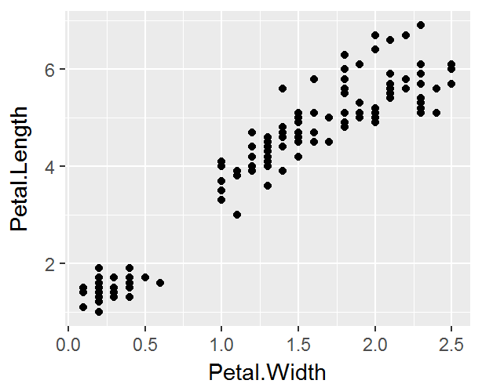

```r
plt
```

## Real example: scatter plots

**STEP 3**:

Maybe we should improve the axis labels? To do this, we need to "add" labels information using the `labs` function

```r
plt <- plt + labs(x = "Petal Width (cm)", y = "Petal Length (cm)")
plt
```

This just adds some new information about labelling to the prexisting `ggplot` object. Now it prints with improved axis labels:

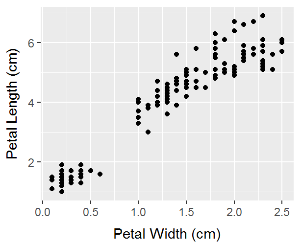

## Example: Scatter plots

**Doing it all in one go…**:

We don't have to build a plot object up in separate steps and then explicitly "print" it to the Console. If we just want to make the plot in one go we can do it like this:

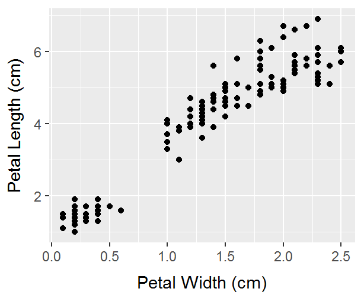

```r
ggplot(iris, aes(x = Petal.Width, y = Petal.Length)) +
  geom_point() +
  labs(x = "Petal Width (cm)", y = "Petal Length (cm)")
```

## Exercise

**Customising your plot**

Repeat the example we just stepped through, but now try to customise the point colours and their size. If that's too easy, see if you can make the points transparent. An example of suitable output is given below.

Hint: The `geom_point` function is responsible for altering these features (it takes a number of different arguments). It has arguments that control things like colour and size. They have sensible names…

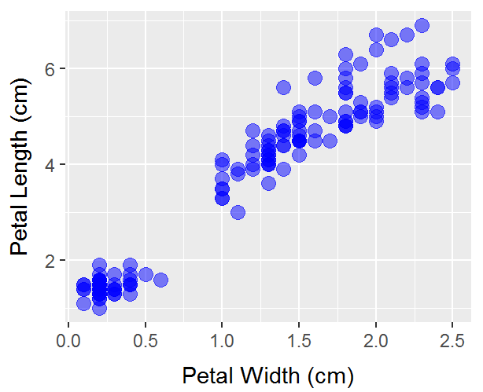

## Answer

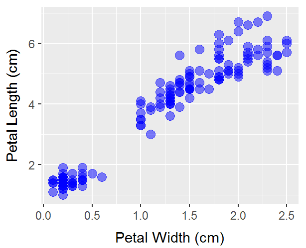

```r
ggplot(iris, aes(x = Petal.Width, y = Petal.Length)) +
  geom_point(colour = "blue", size = 3, alpha = 0.5) +
  labs(x = "Petal Width (cm)", y = "Petal Length (cm)")
```

## Adding more information

Q: The last graph was quite nice, but what information was missing?

A: The species identity!

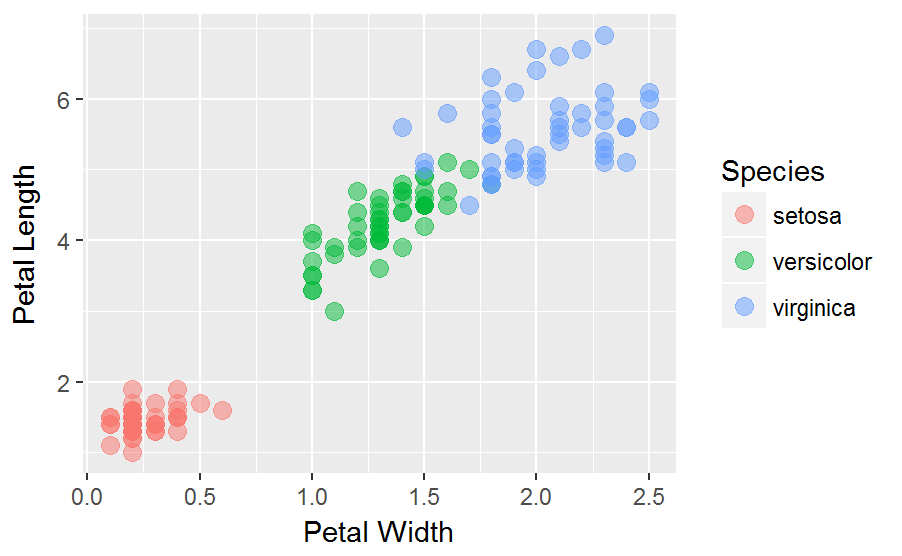

```r
ggplot(iris, aes(x = Petal.Width, y = Petal.Length, colour = Species)) +
  geom_point(size = 3, alpha = 0.5) +
  labs(x = "Petal Width", y = "Petal Length")
```

## Exercise

**Aesthetic mappings vs. arguments to `geom_`**

You may have noticed that we can set something like "colour" in two places: the aesthetic mapping (`aes`) or via an argument to a geom (`geom_`). What happens if we set the colour in both places at once? Experiment with the iris petal length vs. petal width scatter plot example to work this out. Which one—the aesthetic mapping or geom argument—has precedence?

## Exercise

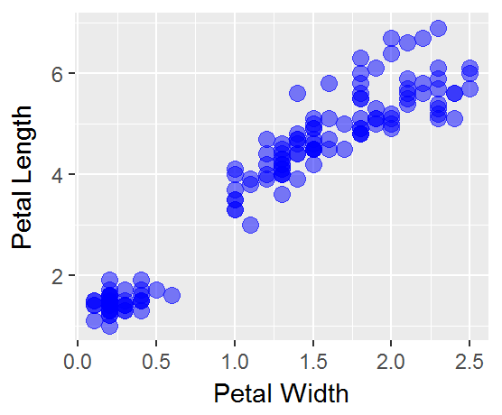

```r
ggplot(iris, aes(x = Petal.Width, y = Petal.Length, colour = Species)) +
  geom_point(colour = "blue", size = 3, alpha = 0.5) +
  labs(x = "Petal Width", y = "Petal Length")
```

## Exercise

**Using `dplyr` and `ggplot2` together (part 1)**

The first step is to work out how to use `dplyr` to calcuate the mean `wind` speed and mean `pressure` for each combination of storm `name` and `type`. Do this with the pipe (`%>%`) operator, and give the resulting data the name `storms.summary`.

```r
storms.summary <-
  storms %>%
  group_by(name, type) %>%
  summarise(wind = mean(wind), pressure = mean(pressure))
```

## Exercise

**Using `dplyr` and `ggplot2` together (part 2)**

The next step uses the `storms.summary` data to plot the mean `wind` speed and mean `pressure` for each name-type case. Remember to colour the points by `type`.

## Exercise

```r
ggplot(storms.summary,
       aes(x = pressure, y = wind, col = type)) +
  geom_point(alpha = 0.7) +
  labs(x = "Mean pressure (mbar)", y = "Mean wind speed (mph)")
```

[output not shown]

## Exercise

**Using `dplyr` and `ggplot2` together (part 3)**

Finally, see if you can combine the solutions to part 1 and 2 into a single "piped" operation. That is, instead of storing the intermediate data in `storms.summary`, use the pipe (`%>%`) to send the data straight to `ggplot`.

## Exercise

```r
storms %>%
  group_by(name, type) %>%
  summarise(wind = mean(wind), pressure = mean(pressure)) %>%
  ggplot(aes(x = pressure, y = wind, col = type)) +
    geom_point(alpha = 0.7) +
    labs(x = "Mean pressure (mbar)", y = "Mean wind speed (mph)")
```

[output not shown]

## Histograms

### Visualising a single variable

## What are histograms?

Histograms summarise the relative frequency of different values of a variable. Look at the first 56 values of `pressure` variable in `storms`:

```r
storms $ pressure[1:56]
```

```
##  [1] 1005 1004 1003 1001  997  995  987  988  988  990  990  993  993  994
## [15]  995  995  992  990  988  984  982  984  989  993  995  996  997 1000
## [29]  997  990  992  992  993 1019 1019 1018 1017 1016 1013 1011 1009 1007
## [43] 1004 1001  997  997  997  997  996  995  993  991  990  989 1012 1012
```

To get a sense of how frequent different values are we can "bin" the data. Here are the frequencies of `pressure` variable values, using 8 bins:

```r
table(cut(storms $ pressure, breaks = 8))
```

```
##
##        (905,919]        (919,934]        (934,948]        (948,962]
##                5               23               80              164
##        (962,976]        (976,990]      (990,1e+03] (1e+03,1.02e+03]
##              307              558              943              667
```

(You don't need to remember this R code)

## What are histograms?

We use histograms to understand the **distribution** of a variable. They summarise the number of observations occuring in a contiguous series of bins. We can use `geom_histogram` to construct a histogram. Here is an example:

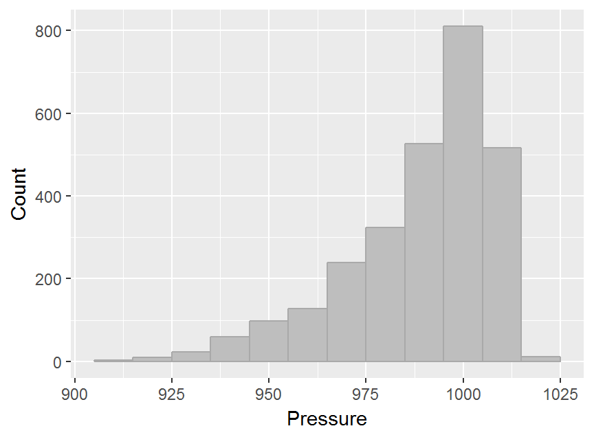

```r
ggplot(storms, aes(x = pressure)) +
  geom_histogram(colour = "darkgrey", fill = "grey", binwidth=10) +
  labs(x = "Pressure", y = "Count")
```

## Exercise

**Plotting histograms**

Working with the `iris` dataset, construct a histogram of the ratio of petal length to petal width. See if you can make you histogram look like the one below.  
Hint: you can carry out the calculation with `Petal.Length` and `Petal.Width` inside `aes` (you don't have to first use `mutate` from `dplyr`)

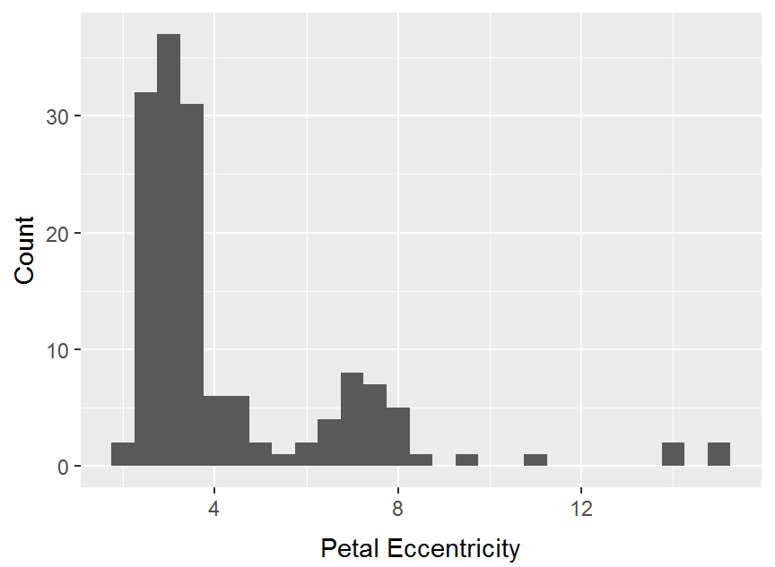

## Answer

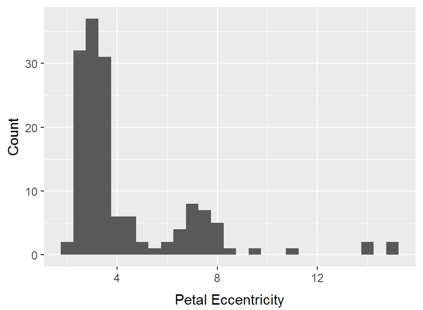

```r
ggplot(iris, aes(x = Petal.Length / Petal.Width)) +
  geom_histogram(binwidth=0.5) +
  labs(x = "Petal Eccentricity", y = "Count")
```

## Alternative to histograms

### visualising 'small' data

## Dot plots

We use dot plots to explore the **distribution** of variables when we have relatively few observations (e.g. < 100). Here is an example:

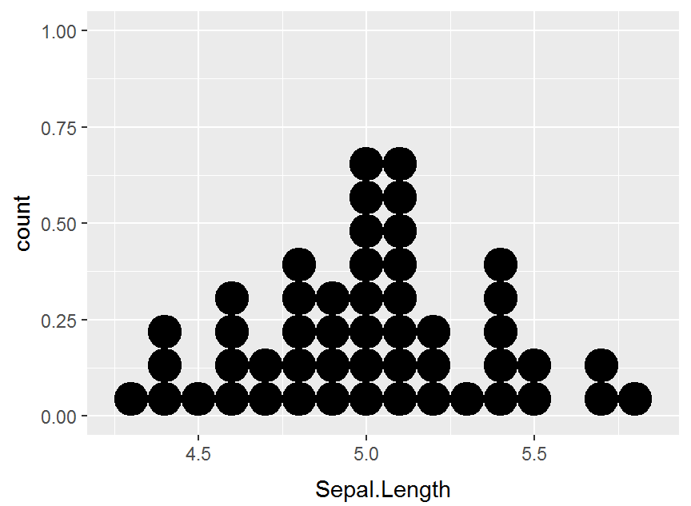

```r
setosa <- filter(iris, Species == "setosa")
ggplot(setosa, aes(x = Sepal.Length)) +
  geom_dotplot(binwidth=0.1)
```

## Saving plots

We can save our plots using the `ggsave` function as follows

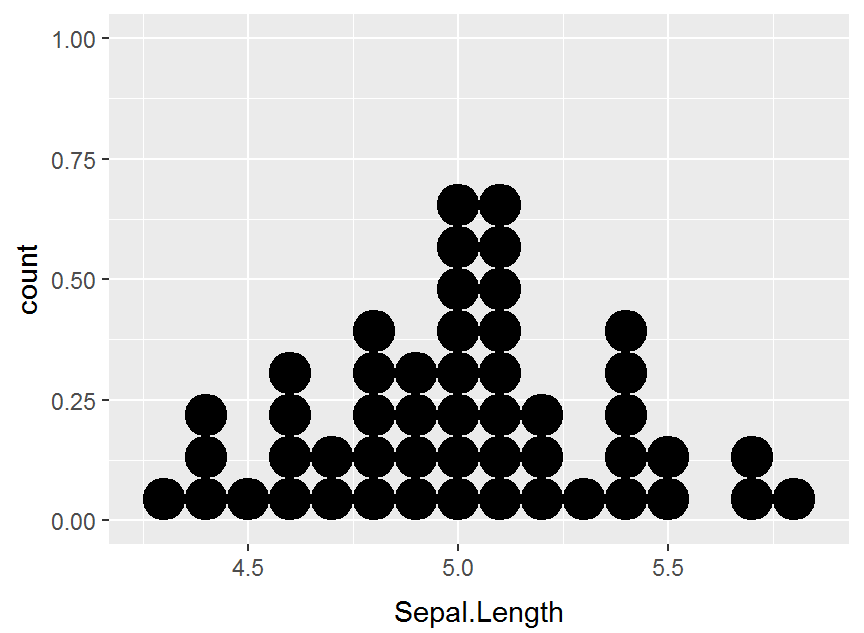

```r
ggplot(setosa, aes(x = Sepal.Length)) +
  geom_dotplot(binwidth=0.1) +
  ggsave("Sepal_dotplot.pdf", height = 4, width =4)
```

## Exercise

**Saving plots**

## Answer

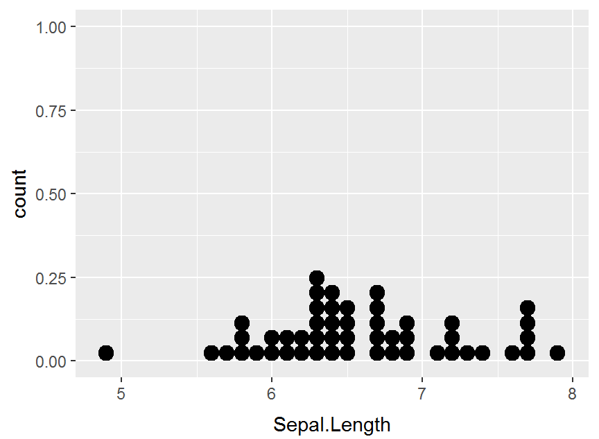

```r
virginica <- filter(iris, Species== "virginica")
ggplot(virginica, aes(x = Sepal.Length)) +
  geom_dotplot(binwidth=0.1) +
  ggsave("Sepal_dotplot.pdf", height = 4, width =4)
```

## What happens next?

1. **No lecture** tomorrow.
2. Course book, course book, course book!
3. Let me know if you need help
4. More plotting next week (Then we're done…)